# 7章 統計グラフ

azu

2015年8月15日

> R に組み込まれた機能や、lattice パッケージや ggplot2 パッケージのように後から追加 できるパッケージの形で、優れたグラフィクスの機能を提供します

> グラフィクスは統計学において、主に 2 つの理由で使用されます。1 つは探索的データ 解析(exploratory data analysis, EDA)、そしてもう1つは結果の説明のためです。

## 7.1 : 基本グラフィクス

Rに組み込まれてるデータセットは小さいので、ggplot2を使おう。

```r
require(ggplot2)
data(diamonds)
head(diamonds)
```

```
##   carat       cut color clarity depth table price    x    y    z
## 1  0.23     Ideal     E     SI2  61.5    55   326 3.95 3.98 2.43
## 2  0.21   Premium     E     SI1  59.8    61   326 3.89 3.84 2.31
## 3  0.23      Good     E     VS1  56.9    65   327 4.05 4.07 2.31
## 4  0.29   Premium     I     VS2  62.4    58   334 4.20 4.23 2.63
## 5  0.31      Good     J     SI2  63.3    58   335 4.34 4.35 2.75
## 6  0.24 Very Good     J    VVS2  62.8    57   336 3.94 3.96 2.48
```

## 7.1.1 : 基本グラフィクスのヒストグラム

ヒストグラム ある変数の値の分布を示す。

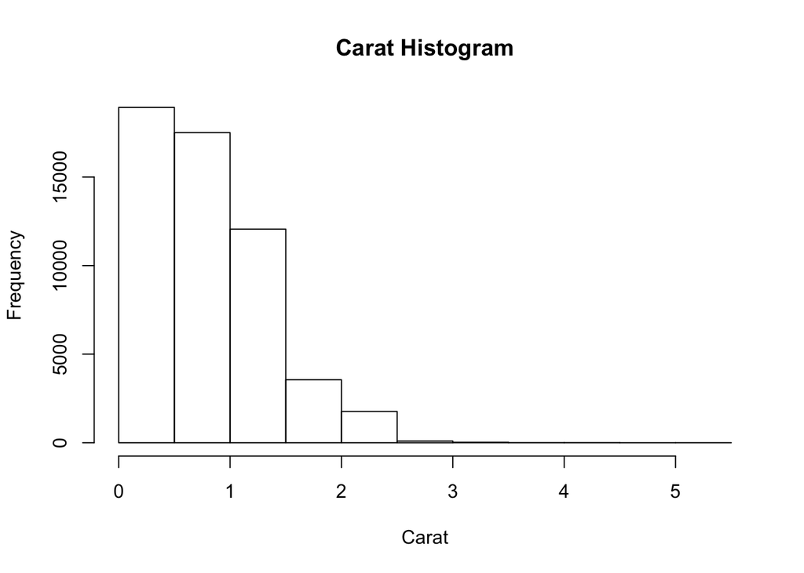

```r
hist(diamonds$carat, main = "Carat Histogram", xlab = "Carat")
```

ダイアモンドのキャラットの分布を示している。 X軸のラベルは`xlab`引数で設定されてりう。

## 7.1.2 : 基本グラフィクスの散布図

2つの変数を比べて見るときに散布図をよく使う。 ダイアモンドの価格とキャラット数の散布図を作成する。

まずはRのformula記法を使う

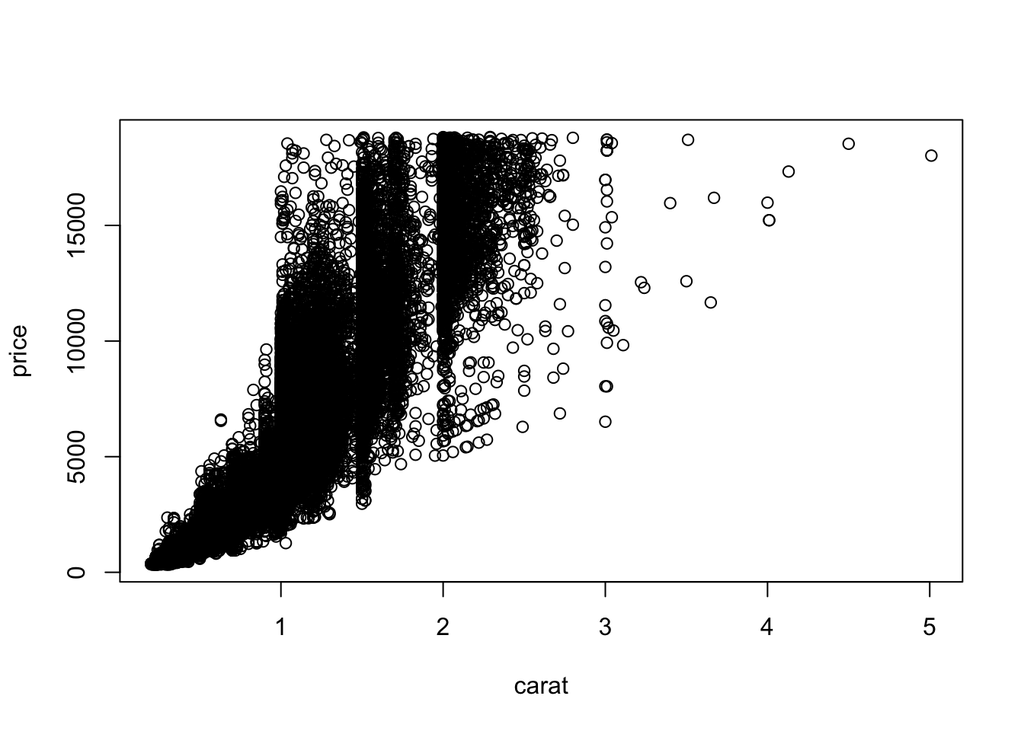

```r
plot(price ~ carat, data = diamonds)
```

`~`はprice と caratを分けている。 キャラットをx軸の値、priceをy軸の値としてる。

fomula記法を使わないでも、plotすることは可能で `plot`に複数のデータを渡してあげればよい。

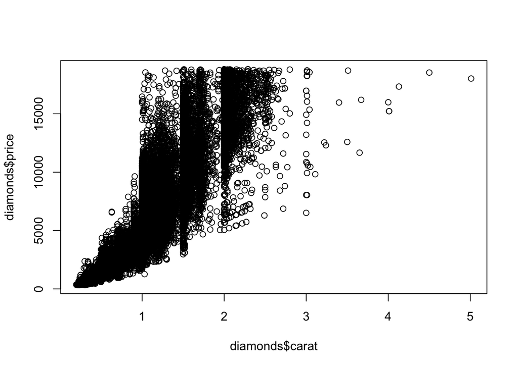

```r
plot(diamonds$carat, diamonds$price)
```

## 7.1.3 : 箱ひげ図

箱ひげ図(boxplot)は色々便利。

`boxplot`という関数で簡単に作れる

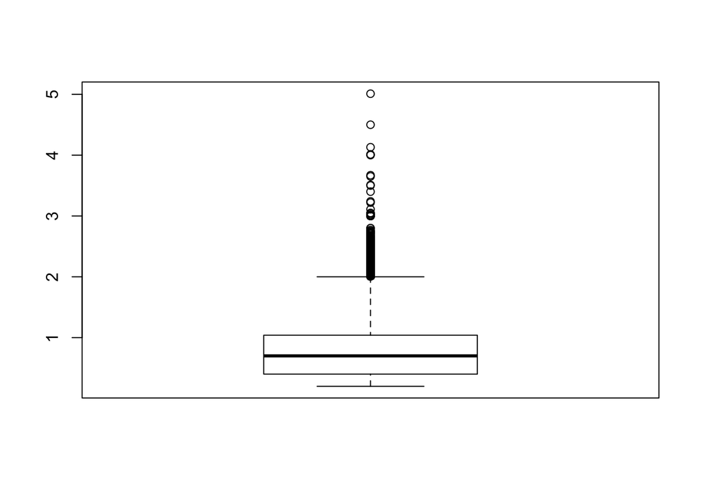

```r
boxplot(diamonds$carat)
```

- 箱の中央の線 = 中央値
- 箱 = 第1、第3/4で囲まれてる。
  - つまりデータの真ん中付近の50%のデータ(IQR)が箱に囲まれている
  - 上下の細い千はIQR * 1.5の位置 = 外れ値

箱の中身が表示されてないけど、箱の中にもデータがある。 外れ値が簡単に分かる?

## 7.2 ggplot2

ggplot2が人気。

```
install.packages("ggplot2", dependencies=TRUE)
```

でインストールして

```r
library(ggplot2)
```

で読み込んで利用する。

```
## stat_bin: binwidth defaulted to range/30. Use 'binwidth = x' to adjust this.
```

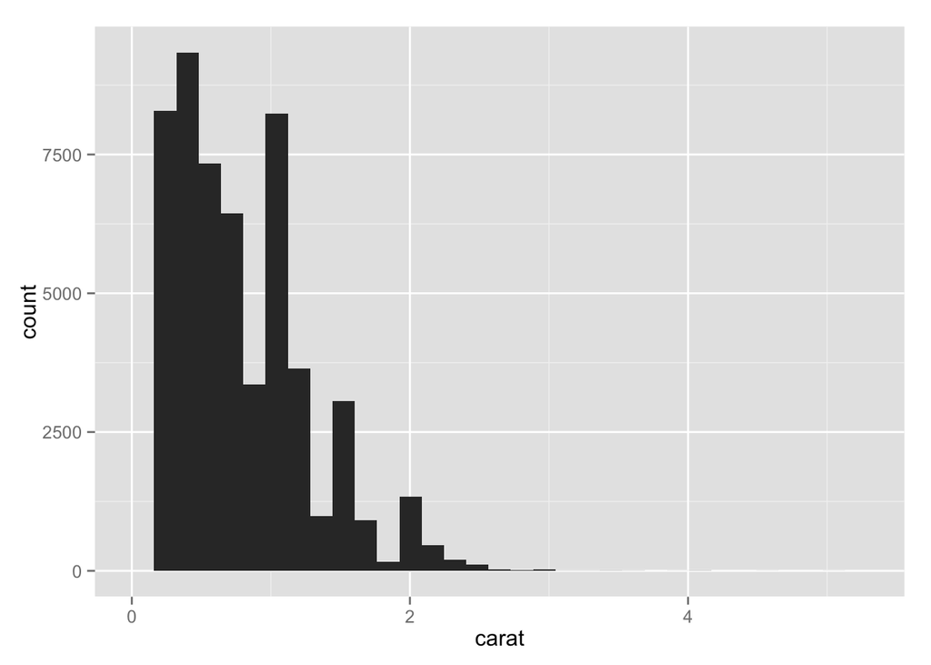

```r
ggplot(data = diamonds) + geom_histogram(aes(x = carat))
```

## 7.2.2 : ggplot2 散布図

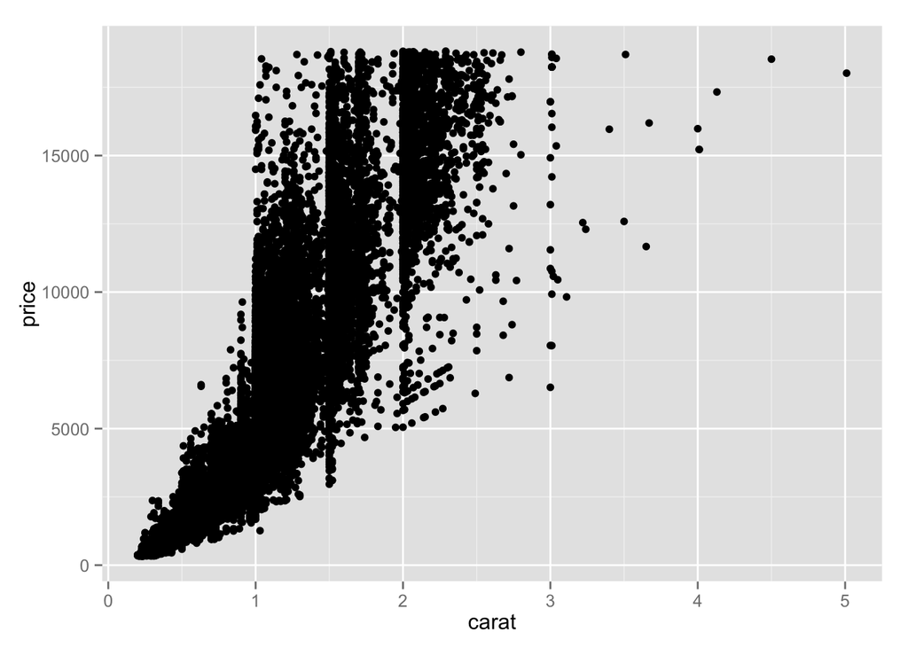

```r
ggplot(diamonds, aes(x = carat, y = price)) + geom_point()
```

ggplot対して、`geom_point()`で散布図のレイヤーを追加する。

`g`変数にggplotオブジェクトを入れる。

```r
g <- ggplot(diamonds, aes(x = carat, y = price))
```

`facet_wrap`で画面枠を追加してみる

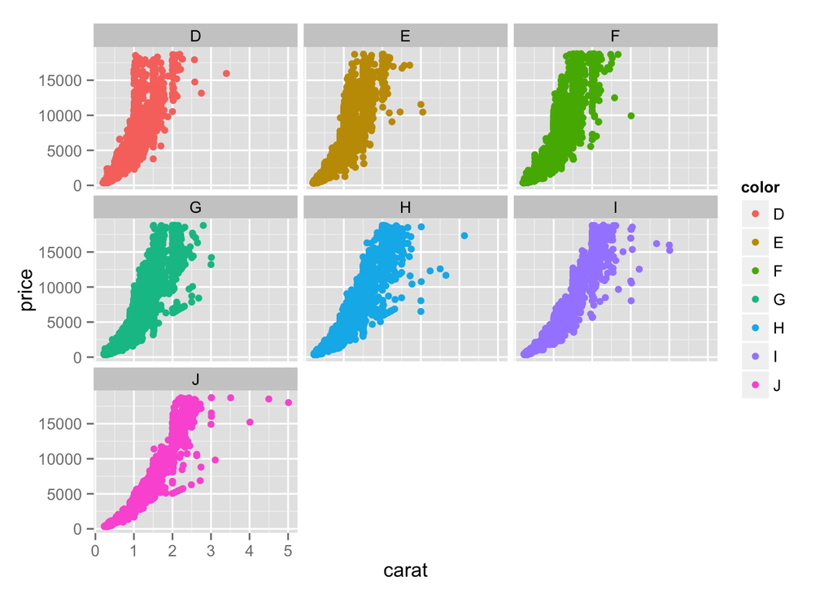

```r
g + geom_point(aes(color = color)) + facet_wrap(~color)
```

## 7.2.3 : ggplot2の箱ひげ図とヴァイオリン・プロット

ggplotでも箱ひげグラフのプロット

`geom_boxplot()`で箱ひげグラフをだせる。 y=キャラット、x=カット数

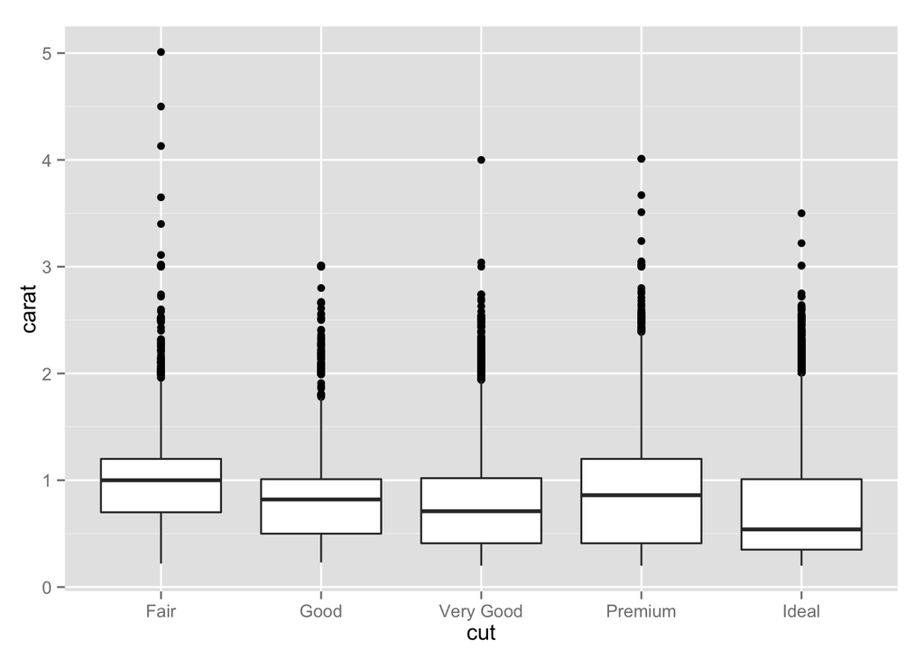

```r
ggplot(diamonds, aes(y = carat, x = cut)) + geom_boxplot()
```

## 7.2.4 : ggplot2における折れ線グラフ

折れ線グラフは連続的なデータを表示しやすいけど、連続性は必須ではない。

エコノミックのデータを日付を扱って、折れ線 `geom_line()`で出してみる

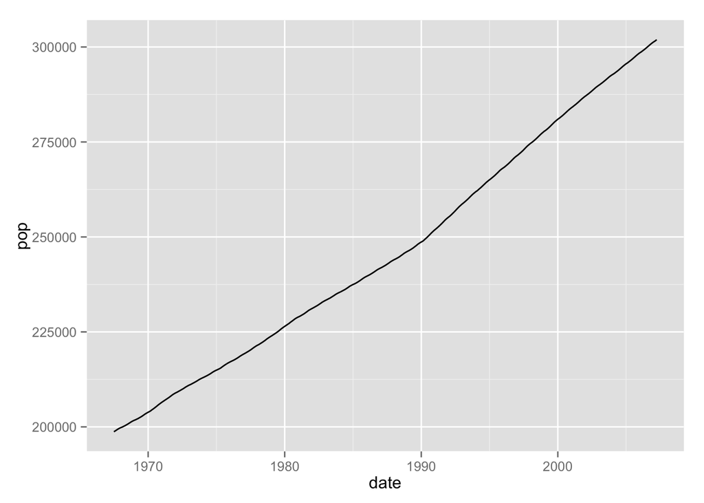

```r
ggplot(economics, aes(x = date, y = pop)) + geom_line()
```

## 7.2.5 : テーマ

ggplotはテーマという機能ががあり、ggthemeというパッケージで簡単に扱える。

```r
require(ggthemes)
```

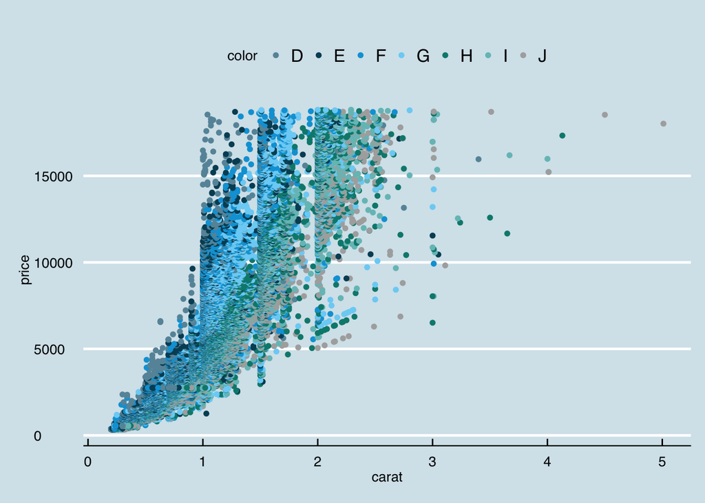

```r
g2 <- ggplot(diamonds, aes(x=carat, y=price)) + geom_point(aes(color = color))

g2 + theme_economist() + scale_colour_economist()
```

ggplotは+で色々追加していく。